# 02_GEMSx003.0w2_Hands-On_Material

[figure not shown]

# Geocomputation with Vector Data in R

## Instructors

Ali Joglekar, University of Minnesota (joglekar@umn.edu)  
Yuan Chai, University of Minnesota (chaix026@umn.edu)

## Hands-On Material Outline

- Geocomputation Intro
- Vector Data Review
- Attribute Data Operations
  - Exercise 1
- Spatial Data Operations
  - Exercise 2
- Geometry Operations
  - Exercise 3

## Setup

### Load R Packages

```r
packages_to_load <- c("sf", "terra", "tmap", "spData")

for ( package in packages_to_load ) {
    # Check if package is already installed, if not, install and load the package
    if (!require(package, character.only=T, quietly=T, warn.conflicts=F)) {
        install.packages(package)
        suppressPackageStartupMessages(library(package, character.only=T, quietly=T, warn.conflicts=F))
    }
}
```

Note: For your own work, once packages are installed, it is recommended to just use `library()` to load your packages

```r
# Spatial data libraries
library(sf)
library(terra)
library(spData)

# Plotting libraries
library(tmap)
```

### Data

Your exercises will draw on three vector data sets from the Minnesota Geospatial Commons, which have been downloaded, cleaned, transformed and saved in the directory `../data/MN` for this workshop.

1. [POINT] Minnesota Six-Inch Soil Temperature: https://gisdata.mn.gov/dataset/geos-soil-temp-network
2. [LINES] Stream Routes - Major River Centerlines: https://gisdata.mn.gov/dataset/water-major-river-centerlines
3. [POLYGONS] Groundwater Provinces of Minnesota 2021: https://gisdata.mn.gov/dataset/geos-groundwater-provinces-mn

### Attribution

The following material draws heavily from Robin Lovelace’s Geocomputation with R textbook.

## What is Geocomputation?

*Geocomputation* is a young term, dating back to the first conference on the subject in 1996, simply defined as the process of “applying computing technology to geographical problems” (Rees and Turton 1998)

- Emphasis on “creative and experimental” applications” (Longley et al. 1998)
- Using various different types of geodata and developing relevant geo-tools within the overall context of a ‘scientific’ approach (Openshaw and Abrahart 2000)

## Vector Data Review

Representation of the world using points, lines, and polygons

- Point: a precise location in space (e.g., weather stations)
- Line: a sequential collection of connected points (e.g., roads)
- Polygon: a region enclosed by lines (e.g., countries)

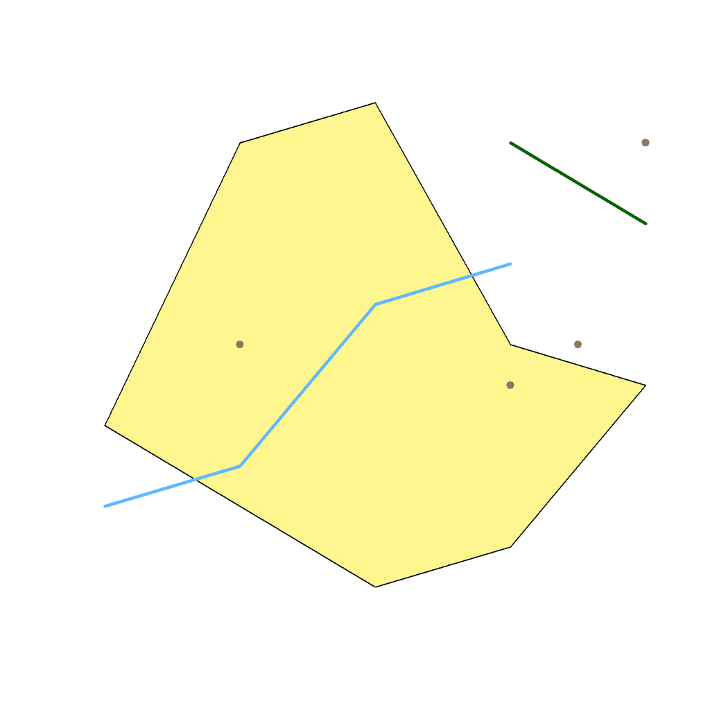

Vector data in R well supported by `sf` class, which extends `data.frame`

- `sf` objects represents points, lines and polygons as discrete entities in space
- `sf` objects have one column per attribute variable and one row per observation, or feature
- `sf` objects have special column that contains geometry data
- `sf` geometry column is a list column -- can contain multiple geographic entities per row
- `sf` enables full power of R’s data analysis capabilities to be unleashed on geographic data

### Attribute Data Operations

Manipulating geographic objects based on attributes

- `subset`
- `aggregation`
- `merge`

### Vector Attribute Manipulation: Subset

Base R subsetting functions include `[` and `subset()`, both of which can be used with `sf` objects

The following code chunk creates a new object containing nations whose surface area is greater than 1 million km2 and smaller than 5 million km2:

```r
world
```

```
## Simple feature collection with 177 features and 10 fields
## Geometry type: MULTIPOLYGON
## Dimension:     XY
## Bounding box:  xmin: -180 ymin: -89.9 xmax: 180 ymax: 83.64513
## Geodetic CRS:  WGS 84
## # A tibble: 177 × 11
##    iso_a2 name_long continent region_un subregion type  area_km2     pop lifeExp
##  * <chr>  <chr>     <chr>     <chr>     <chr>     <chr>    <dbl>   <dbl>   <dbl>
##  1 FJ     Fiji      Oceania   Oceania   Melanesia Sove…   1.93e4  8.86e5    70.0
##  2 TZ     Tanzania  Africa    Africa    Eastern … Sove…   9.33e5  5.22e7    64.2
##  3 EH     Western … Africa    Africa    Northern… Inde…   9.63e4 NA         NA
##  4 CA     Canada    North Am… Americas  Northern… Sove…   1.00e7  3.55e7    82.0
##  5 US     United S… North Am… Americas  Northern… Coun…   9.51e6  3.19e8    78.8
##  6 KZ     Kazakhst… Asia      Asia      Central … Sove…   2.73e6  1.73e7    71.6
##  7 UZ     Uzbekist… Asia      Asia      Central … Sove…   4.61e5  3.08e7    71.0
##  8 PG     Papua Ne… Oceania   Oceania   Melanesia Sove…   4.65e5  7.76e6    65.2
##  9 ID     Indonesia Asia      Asia      South-Ea… Sove…   1.82e6  2.55e8    68.9
## 10 AR     Argentina South Am… Americas  South Am… Sove…   2.78e6  4.30e7    76.3
## # ℹ 167 more rows
## # ℹ 2 more variables: gdpPercap <dbl>, geom <MULTIPOLYGON [°]>
```

```r
mid_countries = world[world$area_km2 > 1000000 & world$area_km2 < 5000000, ]
mid_countries
```

```
## Simple feature collection with 23 features and 10 fields
## Geometry type: MULTIPOLYGON
## Dimension:     XY
## Bounding box:  xmin: -117.1278 ymin: -55.25 xmax: 141.0339 ymax: 83.64513
## Geodetic CRS:  WGS 84
## # A tibble: 23 × 11
##    iso_a2 name_long  continent region_un subregion type  area_km2    pop lifeExp
##    <chr>  <chr>      <chr>     <chr>     <chr>     <chr>    <dbl>  <dbl>   <dbl>
##  1 KZ     Kazakhstan Asia      Asia      Central … Sove… 2729811. 1.73e7    71.6
##  2 ID     Indonesia  Asia      Asia      South-Ea… Sove… 1819251. 2.55e8    68.9
##  3 AR     Argentina  South Am… Americas  South Am… Sove… 2784469. 4.30e7    76.3
##  4 CD     Democrati… Africa    Africa    Middle A… Sove… 2323492. 7.37e7    58.8
##  5 SD     Sudan      Africa    Africa    Northern… Sove… 1850886. 3.77e7    64.0
##  6 TD     Chad       Africa    Africa    Middle A… Sove… 1271695. 1.36e7    52.2
##  7 GL     Greenland  North Am… Americas  Northern… Coun… 2206644. 5.63e4    NA
##  8 ZA     South Afr… Africa    Africa    Southern… Sove… 1216401. 5.45e7    61.0
##  9 MX     Mexico     North Am… Americas  Central … Sove… 1969480. 1.24e8    76.8
## 10 BO     Bolivia    South Am… Americas  South Am… Sove… 1085270. 1.06e7    68.4
## # ℹ 13 more rows
## # ℹ 2 more variables: gdpPercap <dbl>, geom <MULTIPOLYGON [°]>
```

And then maps the two objects together using `tmap`

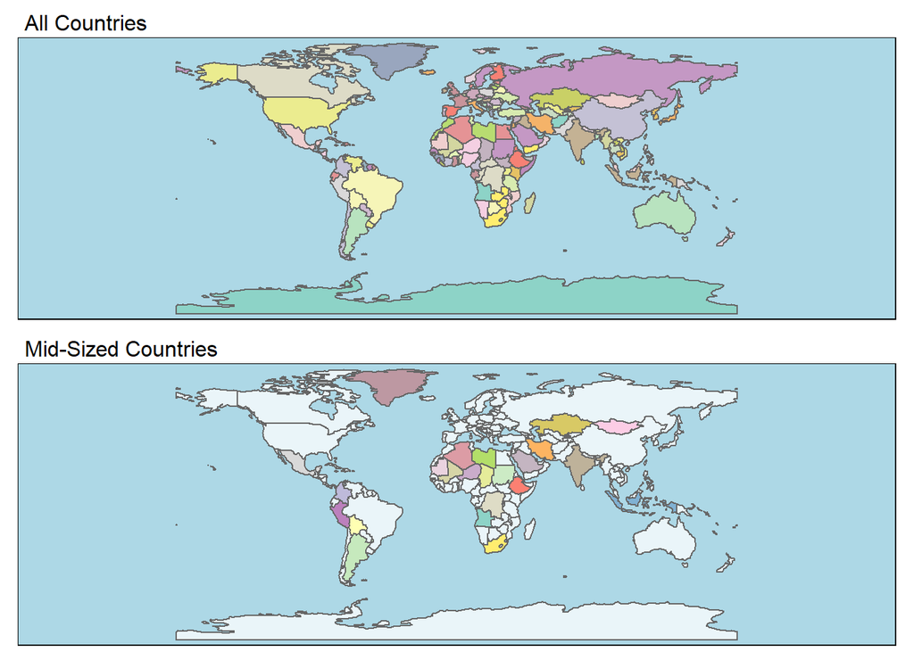

### Vector Attribute Manipulation: Aggregation

Aggregation operations summarize data sets by a ‘grouping variable’, typically an attribute column

The following code chunk calculates the number of people per continent based on country-level data (one row per country):

```r
world_agg = aggregate(world["pop"], by = list(world$continent),
                       FUN = sum, na.rm = TRUE)
```

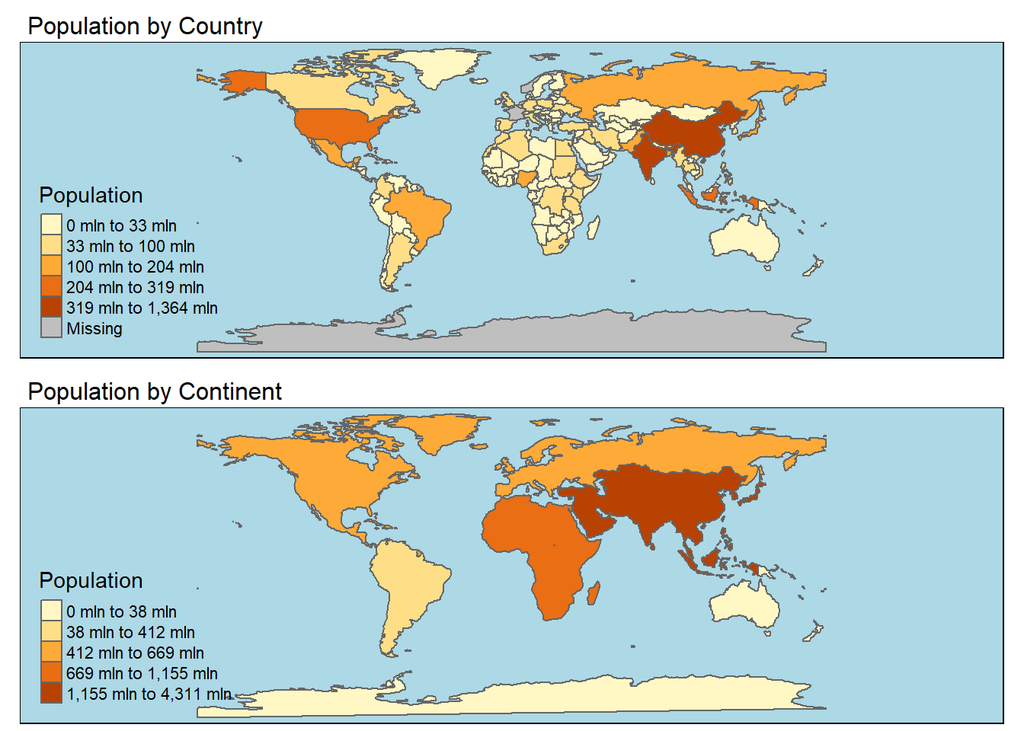

For those of you familiar with the `dplyr` package, you can also use the `group_by()` and `summarize()` functions to aggregate variable(s) of interest across groupings.

```r
library(dplyr)
world_agg2 = world |>
  group_by(continent) |>
  summarize(pop = sum(pop, na.rm = TRUE), area = sum(area_km2))
world_agg2
```

```
## Simple feature collection with 8 features and 3 fields
## Geometry type: GEOMETRY
## Dimension:     XY
## Bounding box:  xmin: -180 ymin: -89.9 xmax: 180 ymax: 83.64513
## Geodetic CRS:  WGS 84
## # A tibble: 8 × 4
##   continent                      pop      area                              geom
##   <chr>                        <dbl>     <dbl>                    <GEOMETRY [°]>
## 1 Africa                  1154946633 29946198. MULTIPOLYGON (((36.86623 22, 36.…
## 2 Antarctica                       0 12335956. MULTIPOLYGON (((-180 -89.9, 180 …
## 3 Asia                    4311408059 31252459. MULTIPOLYGON (((36.14976 35.8215…
## 4 Europe                   669036256 23065219. MULTIPOLYGON (((26.29 35.29999, …
## 5 North America            565028684 24484309. MULTIPOLYGON (((-82.26815 23.188…
## 6 Oceania                   37757833  8504489. MULTIPOLYGON (((166.7932 -15.668…
## 7 Seven seas (open ocean)          0    11603. POLYGON ((68.935 -48.625, 68.867…
## 8 South America            412060811 17762592. MULTIPOLYGON (((-66.95992 -54.89…
```

This approach has more flexibility, readability, and control over the new column names, but does require learning the `tidyverse` syntax.

### Vector Attribute Manipulation: Merge

Merge, or join, operations combine data from different sources based on a shared ‘key’ variable

The following code chunk takes an `sf` object (`world`) as the first argument and adds columns to it from a separate `data.frame` (`coffee_data`) specified as the second argument):

```r
world
```

```
## Simple feature collection with 177 features and 10 fields
## Geometry type: MULTIPOLYGON
## Dimension:     XY
## Bounding box:  xmin: -180 ymin: -89.9 xmax: 180 ymax: 83.64513
## Geodetic CRS:  WGS 84
## # A tibble: 177 × 11
##    iso_a2 name_long continent region_un subregion type  area_km2     pop lifeExp
##  * <chr>  <chr>     <chr>     <chr>     <chr>     <chr>    <dbl>   <dbl>   <dbl>
##  1 FJ     Fiji      Oceania   Oceania   Melanesia Sove…   1.93e4  8.86e5    70.0
##  2 TZ     Tanzania  Africa    Africa    Eastern … Sove…   9.33e5  5.22e7    64.2
##  3 EH     Western … Africa    Africa    Northern… Inde…   9.63e4 NA         NA
##  4 CA     Canada    North Am… Americas  Northern… Sove…   1.00e7  3.55e7    82.0
##  5 US     United S… North Am… Americas  Northern… Coun…   9.51e6  3.19e8    78.8
##  6 KZ     Kazakhst… Asia      Asia      Central … Sove…   2.73e6  1.73e7    71.6
##  7 UZ     Uzbekist… Asia      Asia      Central … Sove…   4.61e5  3.08e7    71.0
##  8 PG     Papua Ne… Oceania   Oceania   Melanesia Sove…   4.65e5  7.76e6    65.2
##  9 ID     Indonesia Asia      Asia      South-Ea… Sove…   1.82e6  2.55e8    68.9
## 10 AR     Argentina South Am… Americas  South Am… Sove…   2.78e6  4.30e7    76.3
## # ℹ 167 more rows
## # ℹ 2 more variables: gdpPercap <dbl>, geom <MULTIPOLYGON [°]>
```

```r
str(coffee_data)
```

```
## tibble [47 × 3] (S3: tbl_df/tbl/data.frame)
##  $ name_long             : chr [1:47] "Angola" "Bolivia" "Brazil" "Burundi" ...
##  $ coffee_production_2016: int [1:47] NA 3 3277 37 8 NA 4 1330 28 114 ...
##  $ coffee_production_2017: int [1:47] NA 4 2786 38 6 NA 12 1169 32 130 ...
```

```r
world_coffee = merge(world, coffee_data, by = "name_long")
world_coffee
```

```
## Simple feature collection with 45 features and 12 fields
## Geometry type: MULTIPOLYGON
## Dimension:     XY
## Bounding box:  xmin: -117.1278 ymin: -33.76838 xmax: 156.02 ymax: 35.49401
## Geodetic CRS:  WGS 84
## First 10 features:
##                   name_long iso_a2     continent region_un       subregion
## 1                    Angola     AO        Africa    Africa   Middle Africa
## 2                   Bolivia     BO South America  Americas   South America
## 3                    Brazil     BR South America  Americas   South America
## 4                   Burundi     BI        Africa    Africa  Eastern Africa
## 5                  Cameroon     CM        Africa    Africa   Middle Africa
## 6  Central African Republic     CF        Africa    Africa   Middle Africa
## 7                  Colombia     CO South America  Americas   South America
## 8                Costa Rica     CR North America  Americas Central America
```

[output cut: 24 more lines]

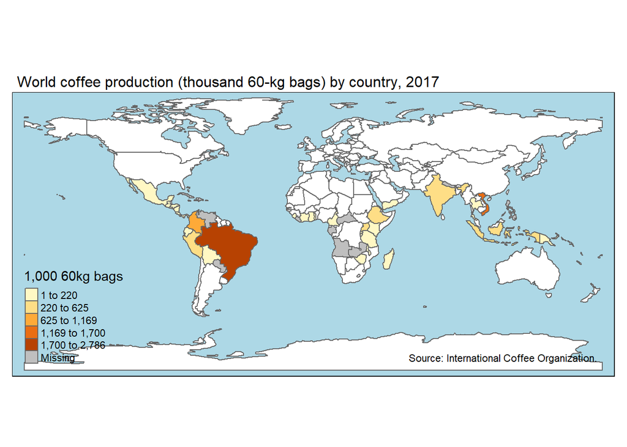

In the majority of cases where variable names are not the same, you have two options:

1. Rename key variables in one of the objects so they match
2. Use the `by` argument to specify the joining variables

```
sf2 <- merge(sf1, dat1, by = "var")
sf2 <- merge(sf1, dat1, by.x = "var1", by.y = "var2")
```

Types of merges

- Inner join preserves matching features from both data sets

```
sf2 <- merge(sf1, dat1, by.x = "var1", by.y = "var2", all = FALSE)
```

- Left (outer) join preserves features from the first data set

```
sf2 <- merge(sf1, dat1, by.x = "var1", by.y = "var2", all.x = TRUE)
```

- Right (outer) join preserves features from the second data set [not generally applicable for spatial data]

```
sf2 <- merge(sf1, dat1, by.x = "var1", by.y = "var2", all.y = TRUE)
```

- Outer join preserves all features from both data sets [not generally applicable for spatial data]

```
sf2 <- merge(sf1, dat1, by.x = "var1", by.y = "var2", all = TRUE)
```

By default, `merge()` performs an inner join: `merge(x, y, by, all = FALSE)`.

```r
world_coffeeI = merge(world, coffee_data, by = "name_long")
nrow(world_coffeeI)
```

```
## [1] 45
```

```r
setdiff(coffee_data$name_long, world$name_long)
```

```
## [1] "Congo, Dem. Rep. of" "Others"
```

The result shows that `name_long` equaling `Congo, Dem. Rep. of` or `Others` is not present in the world dataset. Often country names are abbreviated and easily missed. You can reclassify the DRC name in (either) dataset and remerge. Identifying the spelling of the DRC country name in the world dataset can either be done manually or via a regular expression.

```r
grep("Dem*.+Congo", world$name_long, value = TRUE)
```

```
## [1] "Democratic Republic of the Congo"
```

**Note:** The object order matters when merging `sf` and `data.frame` objects.

- If you list the `sf` object first, the result will be an `sf` object.
- If you list the `data.frame` object first, the result will be a `data.frame` object.

### Exercise 1: Attribute Data Operations

> *Data Source:*  
> Groundwater Provinces shapefile found at `../data/MN/gw_prov/gw_provinces_extra.shp`

For today’s workshop, the data has been downloaded, cleaned, transformed, and saved in the directory `../data/MN`.

1. Find and plot all groundwater provinces in Minnesota that have `var1` equal to “a” and `var3` greater than 100.

```r
# Use this code block to work through the exercise
# Answers are available in separate .RMD file for Exercise 1
```

2. Run the following code:

```r
gw_prov_df <- data.frame(provID = as.character(c(seq(1:5),7)),
                         var4 = sample(c("yes","no"), size = 6, replace = TRUE),
                         var5 = runif(n = 6, min = 10, max = 50))
```

Add variables from `gw_prov_df` to `gw_prov`, and create a new object called `gw_prov_stats`. What function did you use and why? Which variable is key in both data sets? How many observations are in your new object?

```r
# Use this code block to work through the exercise
# Answers are available in separate .RMD file for Exercise 1
```

3. What is the aggregate `var3` by `var1`?

```r
# Use this code block to work through the exercise
# Answers are available in separate .RMD file for Exercise 1
```

## Spatial Data Operations

Modifying geographic objects based on their location and shape

- spatial subset
- topological relations
- spatial joining
- spatial data aggregation

### Vector Spatial Data Operations: Subset

Select features of a spatial object based on whether or not they in some way relate in space to another object

The following code chunk first creates an object representing Canterbury, then uses spatial subsetting to return all high points in the region:

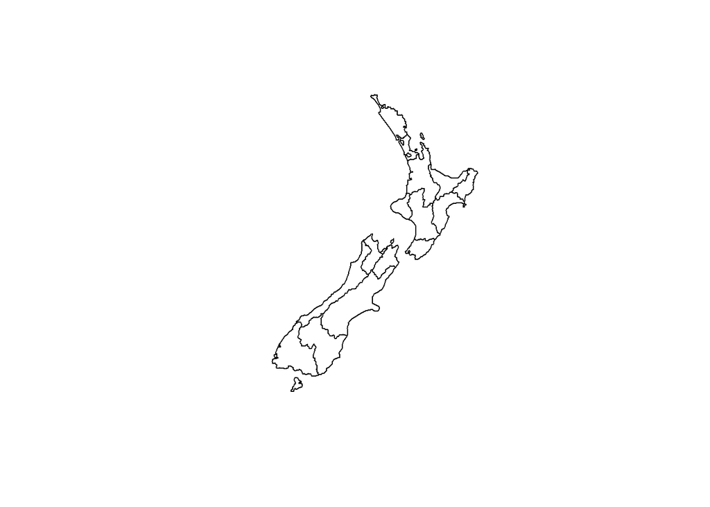

```r
plot(st_geometry(nz))
```

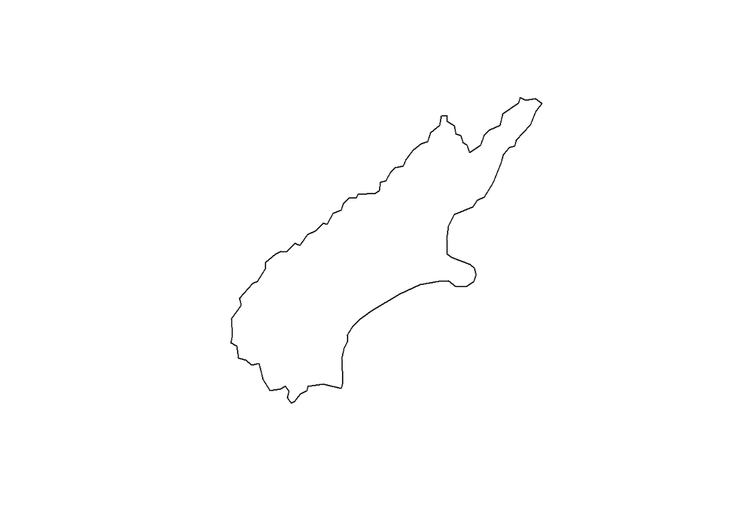

```r
canterbury = nz[nz$Name == "Canterbury",]
plot(st_geometry(canterbury))
```

```r
canterbury_height = nz_height[canterbury, ]
```

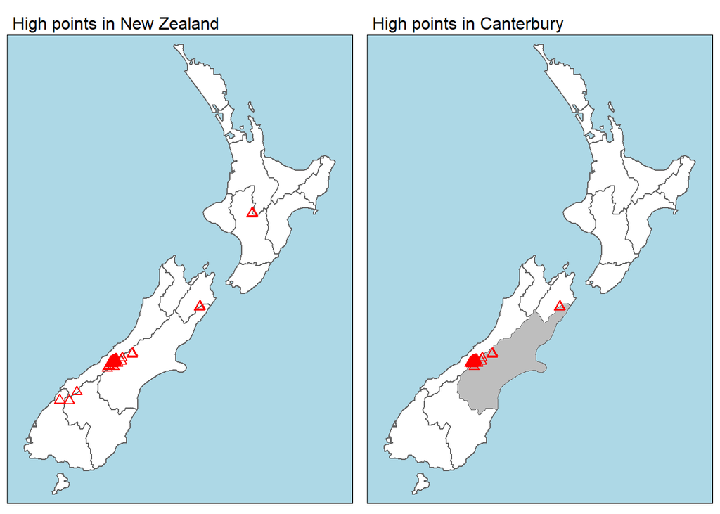

### Vector Spatial Data Operations: Topology

Topological relations describe the spatial relationships between objects

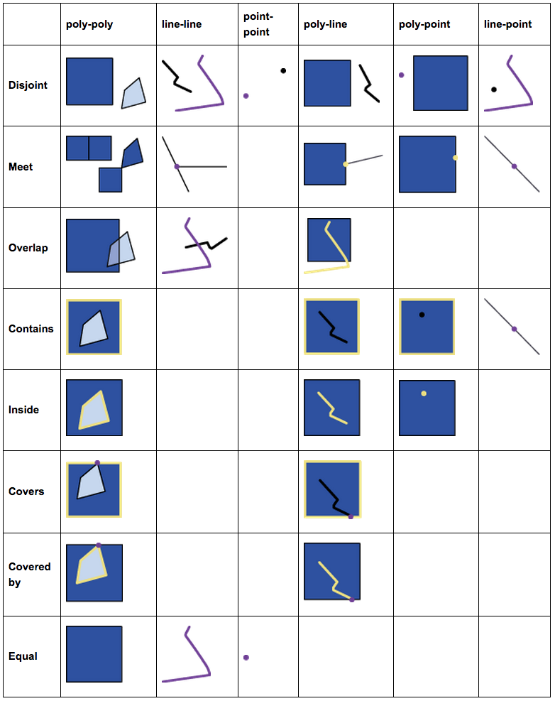

Consider the following figure which contains a polygon (`a`) and some points (`p`).

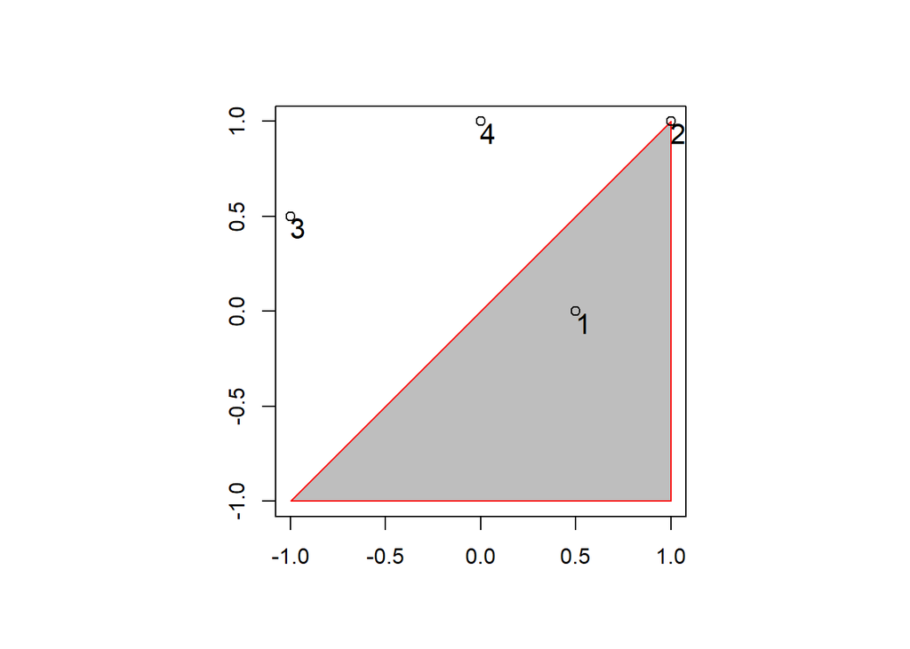

Which of the points in `p` **intersect** in some way with polygon `a`?

```r
sel <- st_intersects(p, a, sparse = F)
sel[,1]
```

```
## [1]  TRUE  TRUE FALSE FALSE
```

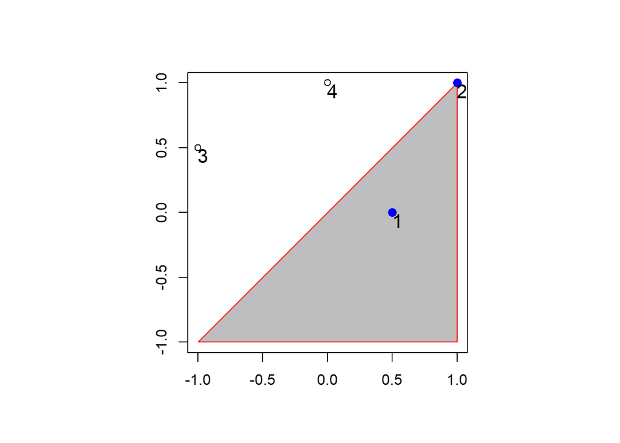

Which of the points in `p` are **disjointed** from polygon `a`?

```r
sel <- st_disjoint(p, a, sparse = F)
sel[,1]
```

```
## [1] FALSE FALSE  TRUE  TRUE
```

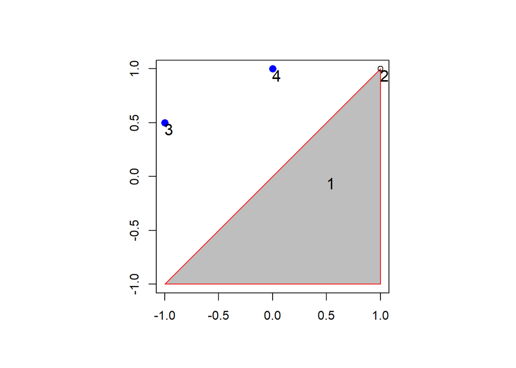

Which of the points in `p` are completely **within** polygon `a`?

```r
sel <- st_within(p, a, sparse = F)
sel[,1]
```

```
## [1]  TRUE FALSE FALSE FALSE
```

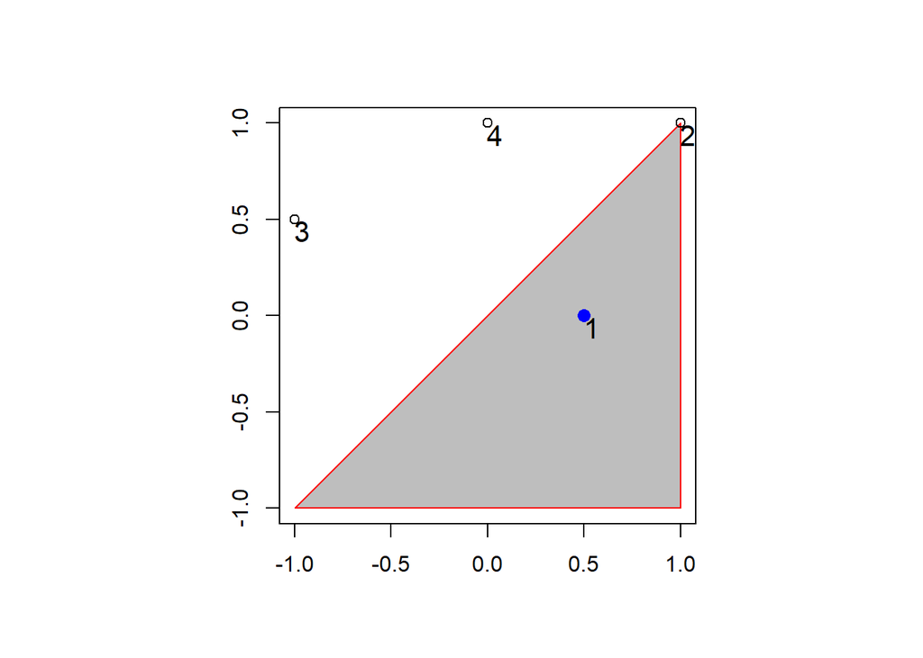

Which of the points in `p` **touch** (the border of) polygon `a`?

```r
sel <- st_touches(p, a, sparse = F)
sel[,1]
```

```
## [1] FALSE  TRUE FALSE FALSE
```

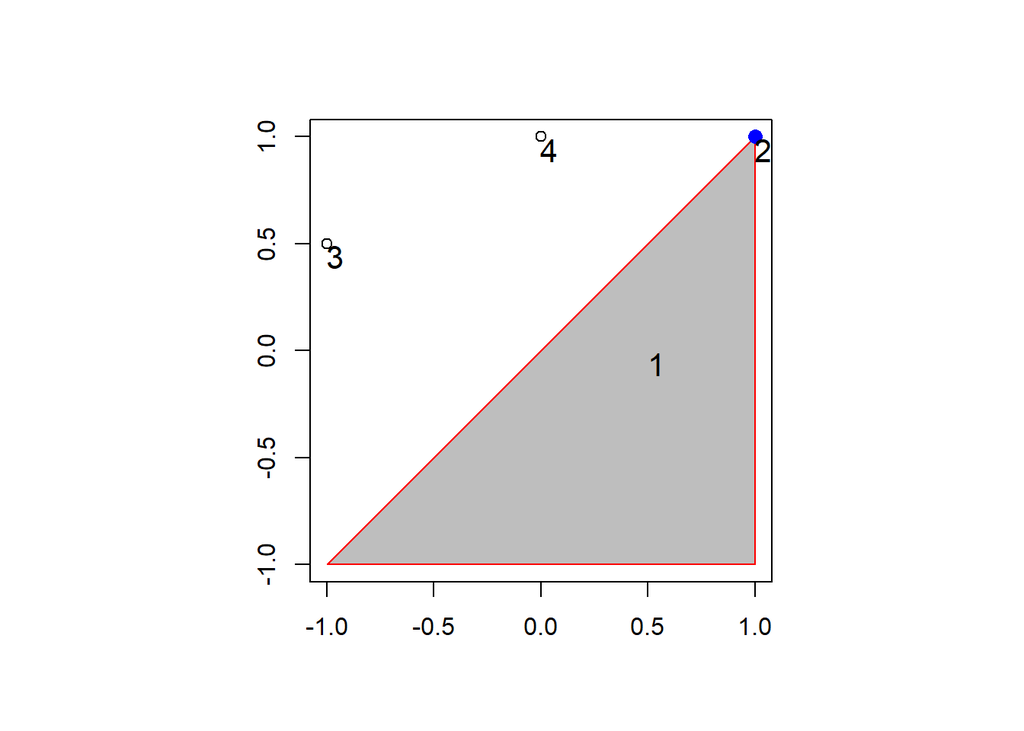

Which of the points in `p` **almost touch** (the border of) polygon `a`?

```r
sel = st_is_within_distance(p, a, dist = 0.9, sparse = F)
sel[,1]
```

```
## [1]  TRUE  TRUE FALSE  TRUE
```

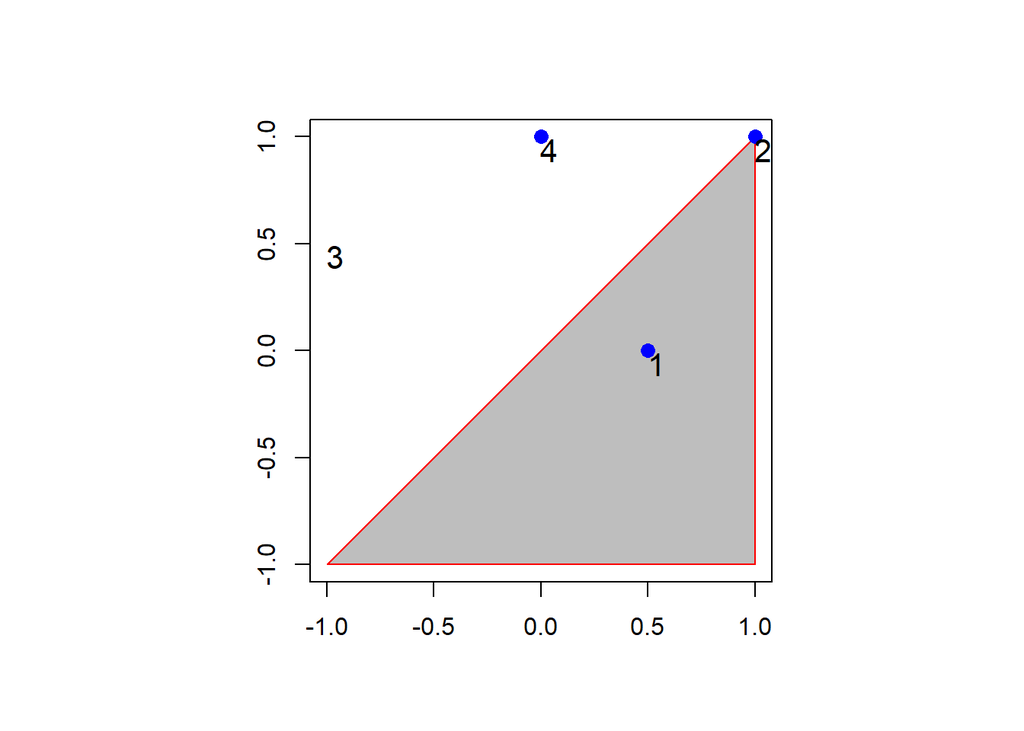

### Vector Spatial Data Operations: Spatial Join

Spatial data joining relies on shared areas of geographic space (*spatial overlay*). Joining adds a new column to the target object (`x`), from a source object (`y`).

The following code chunk determines which countries a set of random points are in:

1. Create set of random points within global bounding box

```r
set.seed(2018) # set seed for reproducibility
bb_world = st_bbox(world) # the world's bounds
random_df = data.frame(
  x = runif(n = 10, min = bb_world[1], max = bb_world[3]),
  y = runif(n = 10, min = bb_world[2], max = bb_world[4])
)
random_points <- st_as_sf(random_df, coords = c("x","y")) # convert to sf object
st_crs(random_points) <- 4326  # set geographic CRS

random_points
```

```
## Simple feature collection with 10 features and 0 fields
## Geometry type: POINT
## Dimension:     XY
## Bounding box:  xmin: -158.1893 ymin: -42.91501 xmax: 165.1157 ymax: 80.5408
## Geodetic CRS:  WGS 84
##                       geometry
## 1  POINT (-58.98475 -21.24278)
## 2   POINT (-13.05963 25.42744)
## 3    POINT (-158.1893 80.5408)
## 4   POINT (-108.9239 27.80098)
## 5    POINT (-9.246895 49.9822)
## 6   POINT (-71.62251 20.15883)
## 7   POINT (38.43318 -42.91501)
## 8   POINT (-133.1956 6.053818)
## 9    POINT (165.1157 38.16862)
## 10   POINT (16.86581 53.86485)
```

2. Extract countries that intersect with random points (for visualization)

```r
world_random = world[random_points, ]
world_random
```

```
## Simple feature collection with 4 features and 10 fields
## Geometry type: MULTIPOLYGON
## Dimension:     XY
## Bounding box:  xmin: -117.1278 ymin: -27.5485 xmax: 24.02999 ymax: 54.85154
## Geodetic CRS:  WGS 84
## # A tibble: 4 × 11
##   iso_a2 name_long continent   region_un subregion type  area_km2    pop lifeExp
##   <chr>  <chr>     <chr>       <chr>     <chr>     <chr>    <dbl>  <dbl>   <dbl>
## 1 MX     Mexico    North Amer… Americas  Central … Sove… 1969480. 1.24e8    76.8
## 2 PL     Poland    Europe      Europe    Eastern … Sove…  310402. 3.80e7    77.6
## 3 PY     Paraguay  South Amer… Americas  South Am… Sove…  401336. 6.55e6    72.9
## 4 MA     Morocco   Africa      Africa    Northern… Sove…  591719. 3.43e7    75.3
## # ℹ 2 more variables: gdpPercap <dbl>, geom <MULTIPOLYGON [°]>
```

3. Join random points and country name attribute from `world`

```r
random_joined = st_join(random_points, world["name_long"])
random_joined$name_long = as.character(random_joined$name_long)

random_joined
```

```
## Simple feature collection with 10 features and 1 field
## Geometry type: POINT
## Dimension:     XY
## Bounding box:  xmin: -158.1893 ymin: -42.91501 xmax: 165.1157 ymax: 80.5408
## Geodetic CRS:  WGS 84
##    name_long                    geometry
## 1   Paraguay POINT (-58.98475 -21.24278)
## 2    Morocco  POINT (-13.05963 25.42744)
## 3       <NA>   POINT (-158.1893 80.5408)
## 4     Mexico  POINT (-108.9239 27.80098)
## 5       <NA>   POINT (-9.246895 49.9822)
## 6       <NA>  POINT (-71.62251 20.15883)
## 7       <NA>  POINT (38.43318 -42.91501)
## 8       <NA>  POINT (-133.1956 6.053818)
## 9       <NA>   POINT (165.1157 38.16862)
## 10    Poland   POINT (16.86581 53.86485)
```

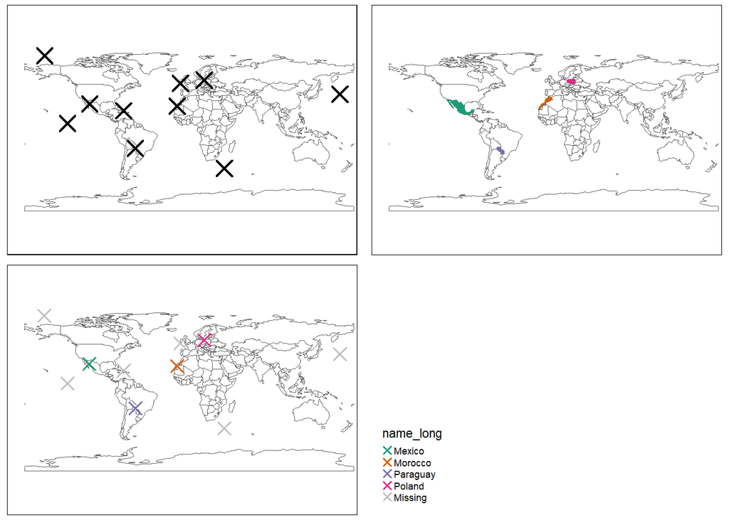

### Vector Spatial Data Operations: Spatial Aggregation

Similar to aggregation by attribute, but instead use the geometry of the source to define how values in the target object are grouped

The following code chunk calculates the average height of high points in each New Zealand region:

```r
nz_avheight = aggregate(x = nz_height, by = nz, FUN = mean)
```

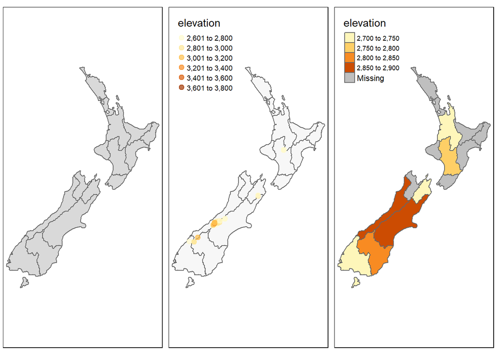

**Reminder:** Spatial aggregations use two different spatial objects, while attribute aggregations use two (or more) attributes within a single spatial object.

```r
nz_popisl = aggregate(x = nz["Population"], by = list(nz$Island), FUN = sum, na.rm = TRUE)
nz_popisl
```

```
## Simple feature collection with 2 features and 2 fields
## Attribute-geometry relationships: aggregate (1), identity (1)
## Geometry type: MULTIPOLYGON
## Dimension:     XY
## Bounding box:  xmin: 1090144 ymin: 4748537 xmax: 2089533 ymax: 6191874
## Projected CRS: NZGD2000 / New Zealand Transverse Mercator 2000
##   Group.1 Population                       geometry
## 1   North    3671600 MULTIPOLYGON (((1865559 546...
## 2   South    1115600 MULTIPOLYGON (((1229730 479...
```

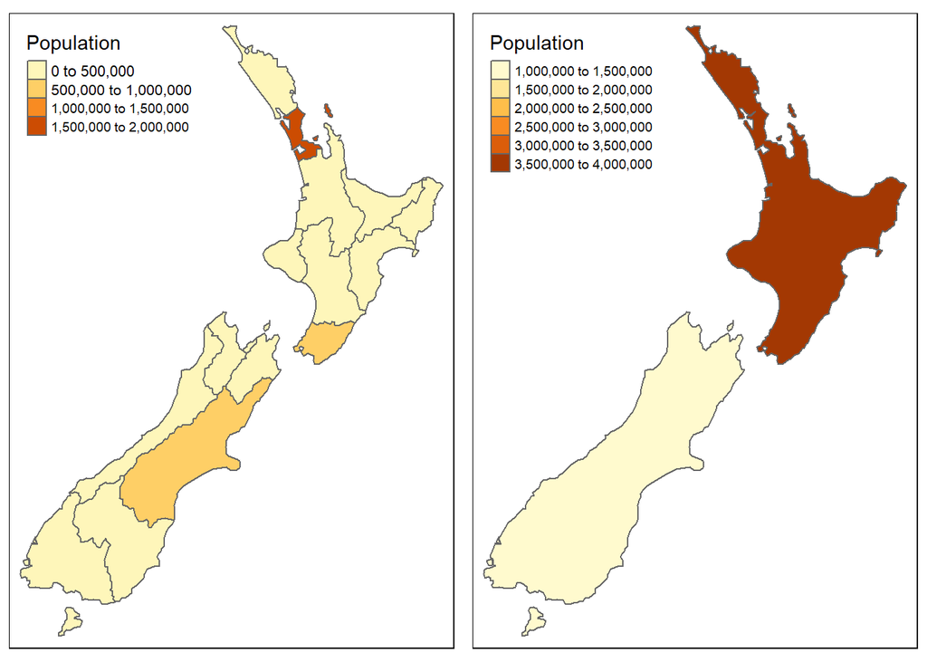

### Exercise 2: Spatial Data Operations

> *Data Sources:*
> - Groundwater Provinces shapefile found at `../data/MN/gw_prov/gw_provinces_extra.shp`
> - Minnesota rivers shapefile found at `../data/MN/stream_routes/mn_rivers.shp`
> - Soil temp stations shapefile found at `../data/MN/soil_temp/soil_temp.shp`

For today’s workshop, the data has been downloaded, cleaned, transformed, and saved in the directory `../data/MN`.

1. Find and plot all the rivers found in groundwater province 5

   ```r
   # Use this code block to work through the exercise
   # Answers are available in separate .RMD file for Exercise 2
   ```

2. Which groundwater province does the Lamberton (soil sample) MDA weather station sit in?

   ```r
   # Use this code block to work through the exercise
   # Answers are available in separate .RMD file for Exercise 2
   ```

3. Find all the weather stations (soil sample sites) that are within 10 km of the Mississippi river.

   ```r
   # Use this code block to work through the exercise
   # Answers are available in separate .RMD file for Exercise 2
   ```

## Geometry Operations

Modifying geographic objects based on their geometry

- centroids
- buffer
- clipping
- geometry unions

### Vector Geometry Operations: Centroids

Centroid operations identify the center of geographic objects.

The most commonly used centroid operation is the *geographic centroid*, which represents the center of mass in a spatial object (think of balancing a plate on your finger)

The following code chunk calculates the centroid of the New Zealand regions and Seine tributaries

```r
nz_centroid = st_centroid(nz)
seine_centroid = st_centroid(seine)
```

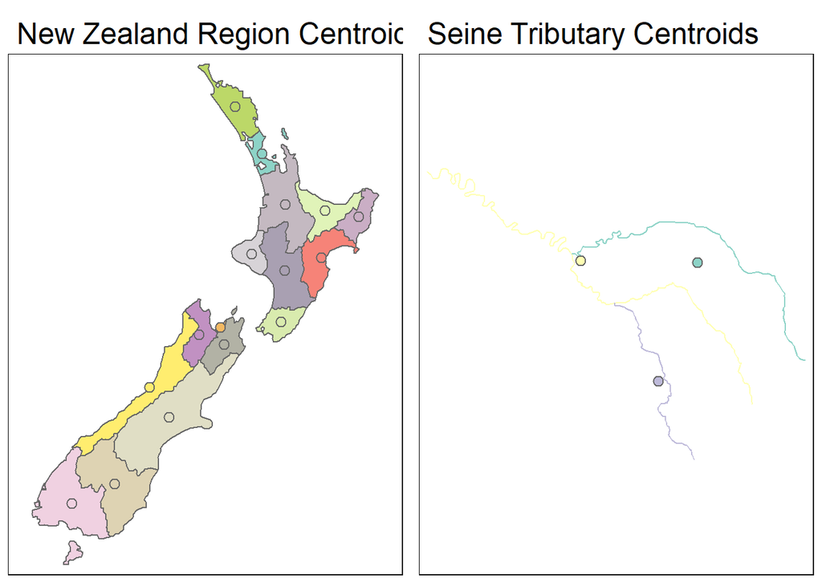

### Vector Geometry Operations: Buffer

Buffers are polygons representing the area within a given distance of a geometric feature: regardless of whether the input is a point, line or polygon, the output is a polygon.

The following chunk calculates buffers around the New Zealand regions and Seine tributaries

```r
nz_buff = st_buffer(nz, dist = 50000)
seine_buff = st_buffer(seine, dist = 5000)
```

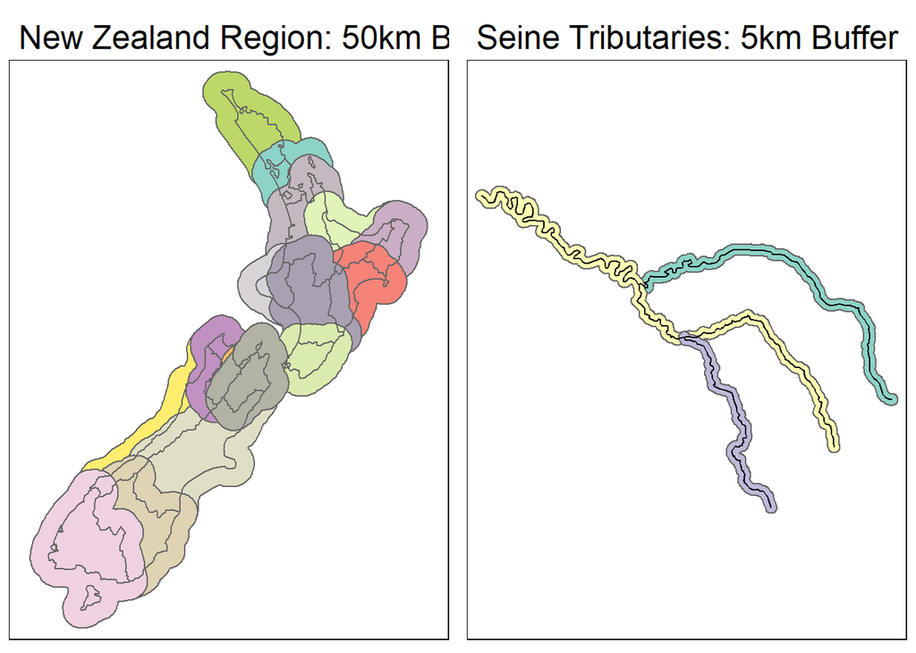

### Vector Geometry Operations: Clipping

Spatial clipping involves changes to the geometry columns of at least some of the affected features

The following figure demonstrates how this works for all combinations of the ‘Venn’ diagram representing object `x` and object `y`.

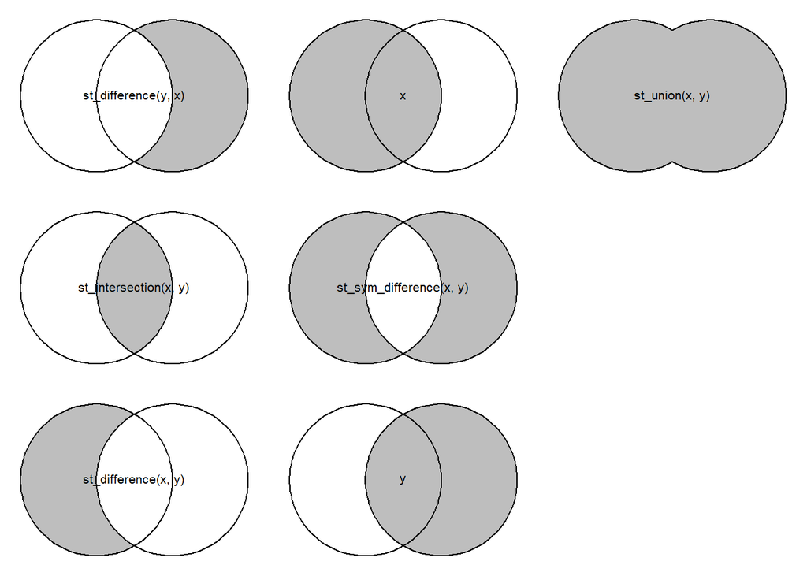

### Vector Geometry Operations: Unions

Spatial unions silently dissolve the geometries of touching polygons in the same group

Remember our aggregation of the number of people per continent based on country-level data:

```r
world_agg = aggregate(world["pop"], by = list(world$continent),
                       FUN = sum, na.rm = TRUE)
```

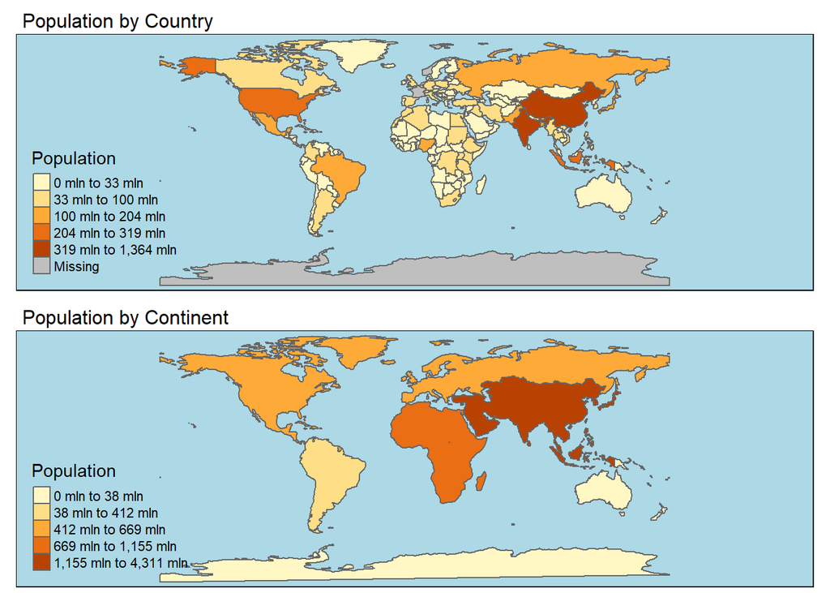

### Exercise 3: Geometry Data Operations

> *Data Source:*
> - Groundwater Provinces shapefile found at `../data/MN/gw_prov/gw_provinces_extra.shp`
> - Minnesota rivers shapefile found at `../data/MN/stream_routes/mn_rivers.shp`

For today’s workshop, the data has been downloaded, cleaned, transformed, and saved in the directory `../data/MN`.

1. Find the centroid of the Mississippi River

   ```r
   # Use this code block to work through the exercise
   # Answers are available in separate .RMD file for Exercise 3
   ```

2. Create a 10km buffer around the Mississippi River

   ```r
   # Use this code block to work through the exercise
   # Answers are available in separate .RMD file for Exercise 3
   ```

3. Find and plot the segments of the Mississippi river that run through groundwater province 1

   ```r
   # Use this code block to work through the exercise
   # Answers are available in separate .RMD file for Exercise 3
   ```